# Superstore Sales Analysis

Author

Nathan Jean-Packard

## Load Libraries

```python
# Import Libraries
import pandas as pd
import numpy as np
import matplotlib.pyplot as plt
import seaborn as sns
```

## Load Data

```python
# Load data
df = pd.read_csv("sales.csv")
df.head()
```

|  | Row ID | Order ID | Order Date | Ship Date | Ship Mode | Customer ID | Customer Name | Segment | Country | City | State | Postal Code | Region | Product ID | Category | Sub-Category | Product Name | Sales |
| --- | --- | --- | --- | --- | --- | --- | --- | --- | --- | --- | --- | --- | --- | --- | --- | --- | --- | --- |
| 0 | 1 | CA-2017-152156 | 08/11/2017 | 11/11/2017 | Second Class | CG-12520 | Claire Gute | Consumer | United States | Henderson | Kentucky | 42420.0 | South | FUR-BO-10001798 | Furniture | Bookcases | Bush Somerset Collection Bookcase | 261.9600 |
| 1 | 2 | CA-2017-152156 | 08/11/2017 | 11/11/2017 | Second Class | CG-12520 | Claire Gute | Consumer | United States | Henderson | Kentucky | 42420.0 | South | FUR-CH-10000454 | Furniture | Chairs | Hon Deluxe Fabric Upholstered Stacking Chairs,... | 731.9400 |
| 2 | 3 | CA-2017-138688 | 12/06/2017 | 16/06/2017 | Second Class | DV-13045 | Darrin Van Huff | Corporate | United States | Los Angeles | California | 90036.0 | West | OFF-LA-10000240 | Office Supplies | Labels | Self-Adhesive Address Labels for Typewriters b... | 14.6200 |
| 3 | 4 | US-2016-108966 | 11/10/2016 | 18/10/2016 | Standard Class | SO-20335 | Sean O'Donnell | Consumer | United States | Fort Lauderdale | Florida | 33311.0 | South | FUR-TA-10000577 | Furniture | Tables | Bretford CR4500 Series Slim Rectangular Table | 957.5775 |
| 4 | 5 | US-2016-108966 | 11/10/2016 | 18/10/2016 | Standard Class | SO-20335 | Sean O'Donnell | Consumer | United States | Fort Lauderdale | Florida | 33311.0 | South | OFF-ST-10000760 | Office Supplies | Storage | Eldon Fold 'N Roll Cart System | 22.3680 |

## Cleaning Data

```python
# Finding rows with N/A
nan_df = df[df.isna().any(axis=1)]
display(nan_df.head())

# Dropping any row that contains at least one NaN in any column
print("Rows before:", len(df))
df = df.dropna(how='any')
print("Rows after:", len(df))
print("Rows dropped:", len(nan_df))
```

|  | Row ID | Order ID | Order Date | Ship Date | Ship Mode | Customer ID | Customer Name | Segment | Country | City | State | Postal Code | Region | Product ID | Category | Sub-Category | Product Name | Sales |
| --- | --- | --- | --- | --- | --- | --- | --- | --- | --- | --- | --- | --- | --- | --- | --- | --- | --- | --- |
| 2234 | 2235 | CA-2018-104066 | 05/12/2018 | 10/12/2018 | Standard Class | QJ-19255 | Quincy Jones | Corporate | United States | Burlington | Vermont | NaN | East | TEC-AC-10001013 | Technology | Accessories | Logitech ClearChat Comfort/USB Headset H390 | 205.03 |
| 5274 | 5275 | CA-2016-162887 | 07/11/2016 | 09/11/2016 | Second Class | SV-20785 | Stewart Visinsky | Consumer | United States | Burlington | Vermont | NaN | East | FUR-CH-10000595 | Furniture | Chairs | Safco Contoured Stacking Chairs | 715.20 |
| 8798 | 8799 | US-2017-150140 | 06/04/2017 | 10/04/2017 | Standard Class | VM-21685 | Valerie Mitchum | Home Office | United States | Burlington | Vermont | NaN | East | TEC-PH-10002555 | Technology | Phones | Nortel Meridian M5316 Digital phone | 1294.75 |
| 9146 | 9147 | US-2017-165505 | 23/01/2017 | 27/01/2017 | Standard Class | CB-12535 | Claudia Bergmann | Corporate | United States | Burlington | Vermont | NaN | East | TEC-AC-10002926 | Technology | Accessories | Logitech Wireless Marathon Mouse M705 | 99.98 |
| 9147 | 9148 | US-2017-165505 | 23/01/2017 | 27/01/2017 | Standard Class | CB-12535 | Claudia Bergmann | Corporate | United States | Burlington | Vermont | NaN | East | OFF-AR-10003477 | Office Supplies | Art | 4009 Highlighters | 8.04 |

```
Rows before: 9800
Rows after: 9789
Rows dropped: 11
```

## Extract Months and Years from Order Date

```python
# Convert order date with day first
df['Order Date'] = pd.to_datetime(df['Order Date'], dayfirst=True)

# Create month and year columns
df['Sale Year'] = df['Order Date'].dt.year
df['Sale Month'] = df['Order Date'].dt.month

# Verify it worked
print(df[['Order Date', 'Sale Year', 'Sale Month']].head(10))
print("Missing years:", df['Sale Year'].isna().sum())
print("Missing months:", df['Sale Month'].isna().sum())
```

```
  Order Date  Sale Year  Sale Month
0 2017-11-08       2017          11
1 2017-11-08       2017          11
2 2017-06-12       2017           6
3 2016-10-11       2016          10
4 2016-10-11       2016          10
5 2015-06-09       2015           6
6 2015-06-09       2015           6
7 2015-06-09       2015           6
8 2015-06-09       2015           6
9 2015-06-09       2015           6
Missing years: 0
Missing months: 0
```

## Getting into the Data

```python
# Sums sales by month and year
sales_summary = df.groupby(['Sale Year', 'Sale Month']).agg(
    total_sales=('Sales', 'sum')
).reset_index()

# Sorts by year and month
sales_summary = sales_summary.sort_values(['Sale Year', 'Sale Month']).reset_index(drop=True)

# Display table
sales_summary
```

|  | Sale Year | Sale Month | total_sales |
| --- | --- | --- | --- |
| 0 | 2015 | 1 | 14205.7070 |
| 1 | 2015 | 2 | 4519.8920 |
| 2 | 2015 | 3 | 55205.7970 |
| 3 | 2015 | 4 | 27906.8550 |
| 4 | 2015 | 5 | 23644.3030 |
| 5 | 2015 | 6 | 34322.9356 |
| 6 | 2015 | 7 | 33781.5430 |
| 7 | 2015 | 8 | 27117.5365 |
| 8 | 2015 | 9 | 81623.5268 |
| 9 | 2015 | 10 | 31453.3930 |
| 10 | 2015 | 11 | 77907.6607 |
| 11 | 2015 | 12 | 68167.0585 |
| 12 | 2016 | 1 | 18066.9576 |
| 13 | 2016 | 2 | 11951.4110 |
| 14 | 2016 | 3 | 32339.3184 |
| 15 | 2016 | 4 | 34154.4685 |
| 16 | 2016 | 5 | 29959.5305 |
| 17 | 2016 | 6 | 23599.3740 |
| 18 | 2016 | 7 | 28608.2590 |
| 19 | 2016 | 8 | 36818.3422 |
| 20 | 2016 | 9 | 63133.6060 |
| 21 | 2016 | 10 | 31011.7375 |
| 22 | 2016 | 11 | 70129.2995 |
| 23 | 2016 | 12 | 74543.6012 |
| 24 | 2017 | 1 | 16870.1810 |
| 25 | 2017 | 2 | 22978.8150 |
| 26 | 2017 | 3 | 51165.0590 |
| 27 | 2017 | 4 | 37385.0170 |
| 28 | 2017 | 5 | 56656.9080 |
| 29 | 2017 | 6 | 39724.4860 |
| 30 | 2017 | 7 | 38320.7830 |
| 31 | 2017 | 8 | 30542.2003 |
| 32 | 2017 | 9 | 69193.3909 |
| 33 | 2017 | 10 | 59583.0330 |
| 34 | 2017 | 11 | 79066.4958 |
| 35 | 2017 | 12 | 95739.1210 |
| 36 | 2018 | 1 | 42839.2940 |
| 37 | 2018 | 2 | 19920.9974 |
| 38 | 2018 | 3 | 58863.4128 |
| 39 | 2018 | 4 | 35541.9101 |
| 40 | 2018 | 5 | 43825.9822 |
| 41 | 2018 | 6 | 48190.7277 |
| 42 | 2018 | 7 | 44825.1040 |
| 43 | 2018 | 8 | 62837.8480 |
| 44 | 2018 | 9 | 86152.8880 |
| 45 | 2018 | 10 | 77448.1312 |
| 46 | 2018 | 11 | 117938.1550 |
| 47 | 2018 | 12 | 82825.3588 |

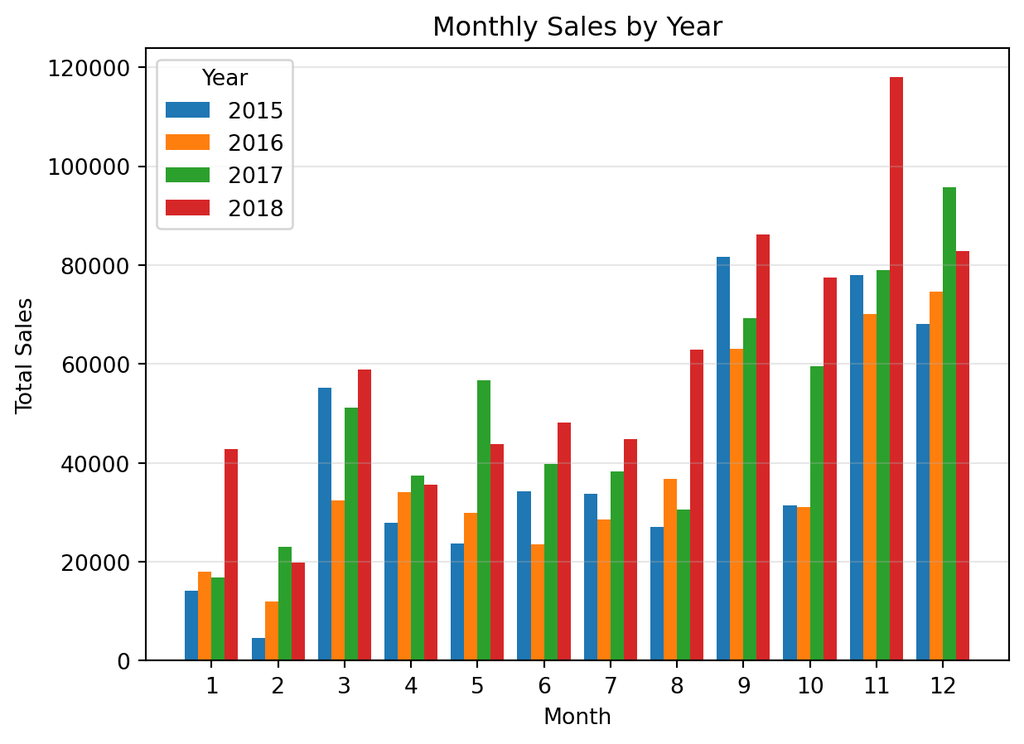

```python
# Sort years and months
years = sorted(sales_summary['Sale Year'].unique())
months = np.arange(1, 13)

bar_width = 0.8 / len(years)

# Loop through the years
for i, year in enumerate(years):

    yearly_data = sales_summary[sales_summary['Sale Year'] == year]

    # Go through month by month
    sales_by_month = []

    for month in months:
        value = yearly_data[yearly_data['Sale Month'] == month]['total_sales']

        # Check if data exists
        if len(value) > 0:
            #Return value
            sales_by_month.append(value.values[0])
        else:
            #Return 0
            sales_by_month.append(0)

    # Plot bars
    plt.bar(
        months + i * bar_width,
        sales_by_month,
        width=bar_width,
        label=str(year)
    )

# Add labels
plt.xlabel('Month')
plt.ylabel('Total Sales')
plt.title('Monthly Sales by Year')

# Center x-axis labels
plt.xticks(
    months + bar_width * (len(years) - 1) / 2,
    months
)

# Add legend and gridlines
plt.legend(title='Year')
plt.grid(axis='y', alpha=0.3)

plt.show()
```

There is a clear pattern over the years of sales being lowest at the beginning of the year, in January and February, then building through the year and spiking in September, November, and December.

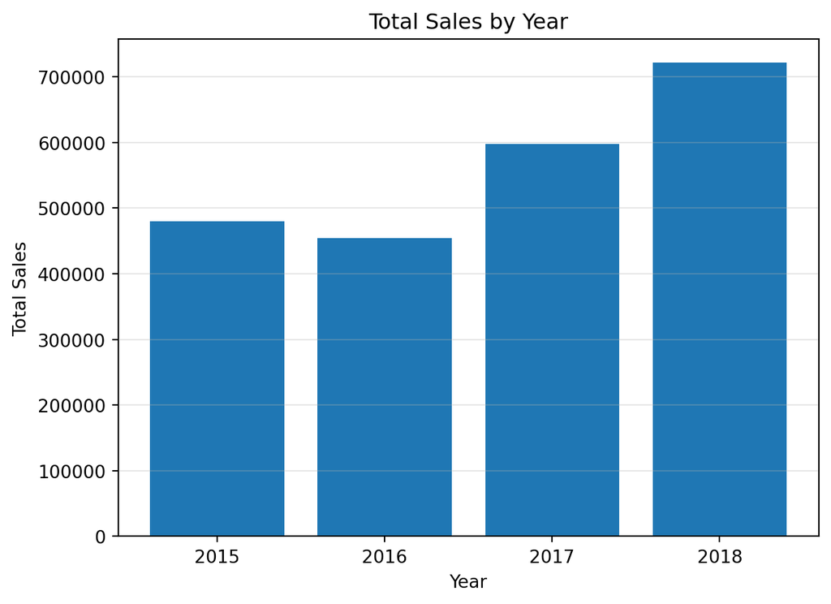

```python
# Get yearly totals
yearly_sales = sales_summary.groupby('Sale Year', as_index=False).agg(
    total_sales=('total_sales', 'sum')
)

# Graph sales by year
plt.bar(
    yearly_sales['Sale Year'],
    yearly_sales['total_sales']
)

# Add labels
plt.xlabel('Year')
plt.ylabel('Total Sales')
plt.title('Total Sales by Year')

# Add gridlines and set tick marks
plt.xticks(yearly_sales['Sale Year'], yearly_sales['Sale Year'])
plt.grid(axis='y', alpha=0.3)

plt.show()
```

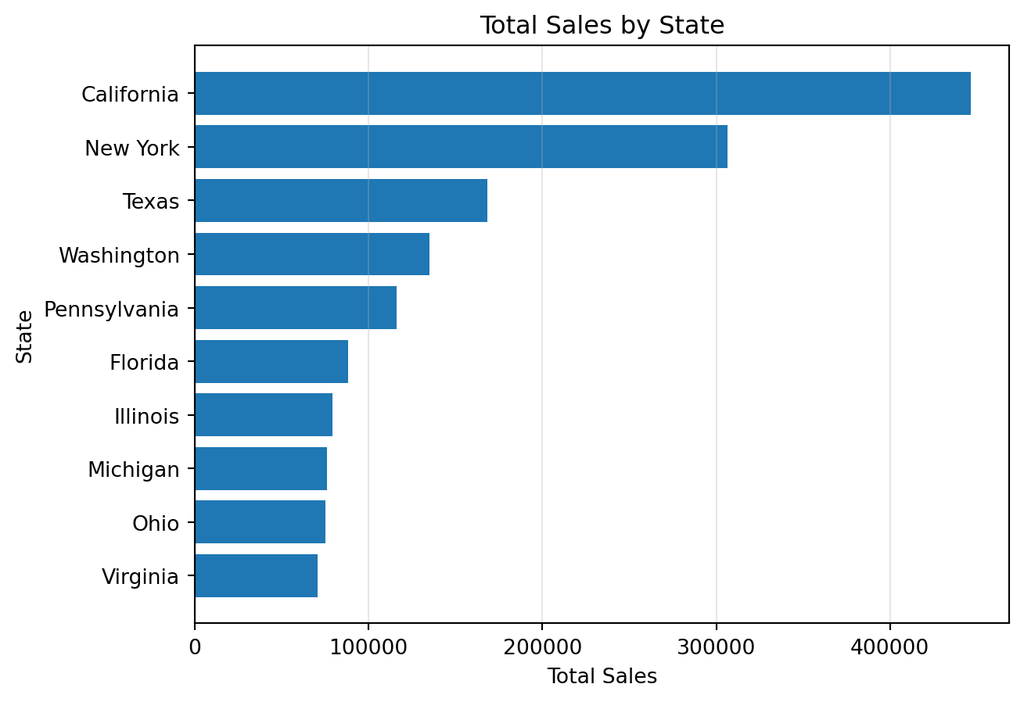

```python
# Get totals by state
state_sales = df.groupby('State', as_index=False).agg(
    total_sales=('Sales', 'sum')
).sort_values('total_sales', ascending=False)

# Only include top 10 selling states
top_states = state_sales.head(10)

# Graph top 10 states
plt.barh(
    top_states['State'],
    top_states['total_sales']
)

# Add labels
plt.xlabel('Total Sales')
plt.ylabel('State')
plt.title('Total Sales by State')

# Put highest at top and add gridlines
plt.gca().invert_yaxis()
plt.grid(axis='x', alpha=0.3)

plt.show()
```

California leads the way in total sales, with New York, Texas, Washington, and Pennsylvania rounding out the top five. All five states have over $100,000 in sales.

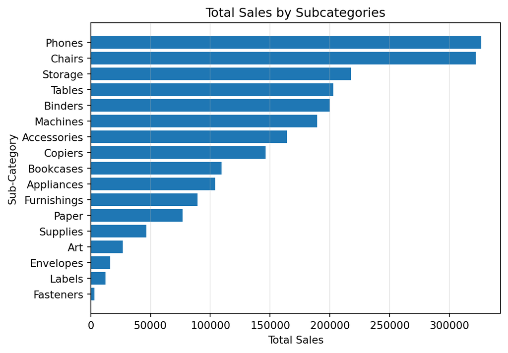

```python
# Get totals by sub category
subcat_sales = df.groupby('Sub-Category', as_index=False).agg(
    total_sales=('Sales', 'sum')
).sort_values('total_sales', ascending=False)

# Graph sales by sub category
plt.barh(
    subcat_sales['Sub-Category'],
    subcat_sales['total_sales']
)

# Add labels
plt.xlabel('Total Sales')
plt.ylabel('Sub-Category')
plt.title('Total Sales by Subcategories')

# Put highest at top and add gridlines
plt.gca().invert_yaxis()
plt.grid(axis='x', alpha=0.3)

plt.show()
```

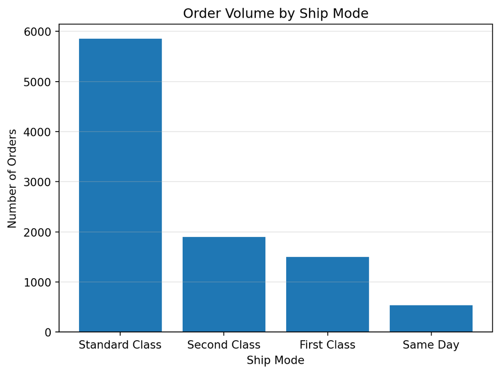

```python
# Get order volume by ship mode
ship_volume = df.groupby('Ship Mode', as_index=False).agg(
    order_count=('Order ID', 'count')
).sort_values('order_count', ascending=False)

# Graph order volume by ship mode
plt.bar(
    ship_volume['Ship Mode'],
    ship_volume['order_count'],
)

# Add labels
plt.xlabel('Ship Mode')
plt.ylabel('Number of Orders')
plt.title('Order Volume by Ship Mode')
plt.grid(axis='y', alpha=0.3)

plt.show()
```

Standard shipping makes up the majority of orders with the number of orders decreasing as the cost of the shipping method increases.

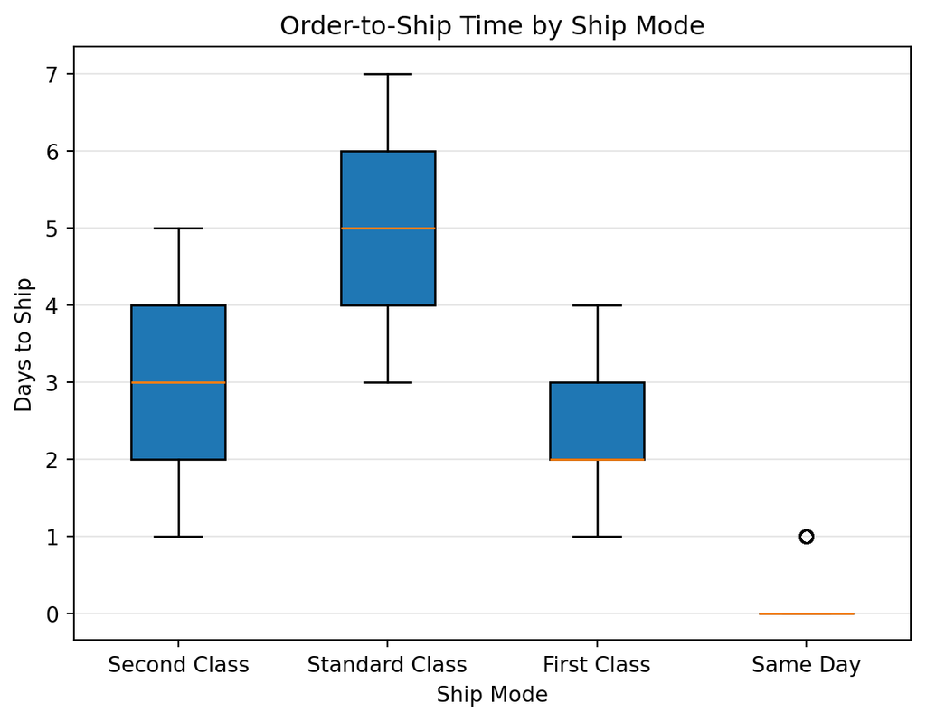

```python
# Convert ship date and calculate fulfillment days
df['Ship Date'] = pd.to_datetime(df['Ship Date'], dayfirst=True)
df['fulfillment_days'] = (df['Ship Date'] - df['Order Date']).dt.days

# Box plot of fulfillment days by ship mode
plt.boxplot(
    [df[df['Ship Mode'] == mode]['fulfillment_days'] for mode in df['Ship Mode'].unique()],
    labels=df['Ship Mode'].unique(),
    patch_artist=True
)

# Add labels
plt.xlabel('Ship Mode')
plt.ylabel('Days to Ship')
plt.title('Order-to-Ship Time by Ship Mode')
plt.grid(axis='y', alpha=0.3)

plt.show()
```

As expected, standard class shipping had the longest order to ship time with an average of 5 days. Second class had an average of 3 days, first class had an average of 2 days, and same day on average was true to its name.

## Data Source

Dataset sourced from Kaggle: [Store Sales Forecasting](https://www.kaggle.com/datasets/rohitsahoo/sales-forecasting/data) by Rohit Sahoo.